# Emendas PIX - A novidade era o máximo

Paulo Bijos

2022-10-06

# Objeto (tema central): Emendas PIX

Esta apresentação tem por objeto de análise as chamadas “emendas PIX”, assim apelidadas por serem fáceis de executar, sem “burocracias”.

[figure not shown]

# O que são as “emendas PIX”?

São novos tipos de emendas ao orçamento federal, criadas pela Emenda Constitucional 105/2019. Oficialmente, recebem o nome de **Transferências Especiais** (ação orçamentária **0EC2**).

O apelido de emendas PIX foi motivado pelo fato de que, na prática, é como se os parlamentares pudessem **apertar um botão** e enviar recursos para suas bases eleitorais - Estados, Distrito Federal ou Municípios, sem “dificuldades”.

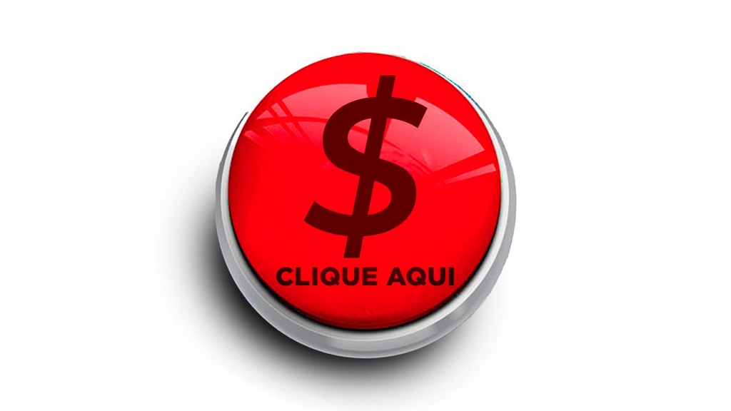

# Objetivo (questão de pesquisa)

O objetivo desta análise é avaliar se essas novas emendas se diferenciam das emendas tradicionais, apresentando **médias mais elevadas** de dotações aprovadas e valores executados. Supõe-se que o mecanismo subjacente a esse processo seja a agregação de diferentes programações em uma nova programação genérica.

Afinal, por poderem financiar praticamente todo tipo de despesas, as emendas PIX também podem gerar o incentivo de **empacotamento** de diferentes objetos de gastos em uma única emenda.

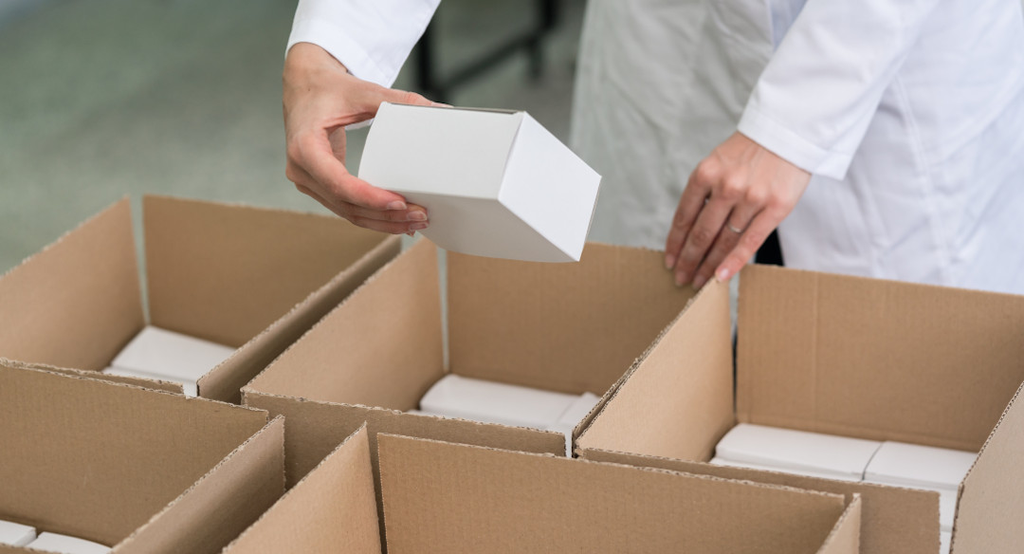

# Contexto (justificativa) - Cheque em branco?

Como as emendas PIX não têm finalidade definida. O ente beneficiário tem ampla liberdade para aplicar os recursos recebidos. Em função disso, tais emendas também são consideradas uma espécie de **“cheque em branco”** assinado pela União em favor dos entes subnacionais.

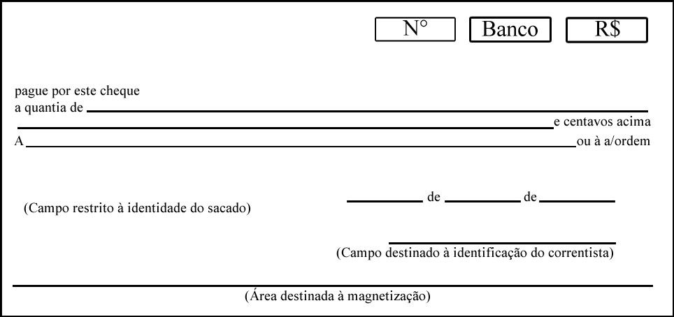

Como agravante, não é o Tribunal de Contas da União (TCU) quem fiscaliza a aplicação dos recursos repassados. Como os recursos transferidos passam a pertencer aos entes beneficiados, quem os fiscaliza são os tribunais de contas dos estados (TCEs) ou dos municípios, quando houver (casos de RJ e SP).

# Contexto (justificativa) - Rápida difusão

Com todas essas faciidades, as emendas PIX tornaram-se bastante populares entre os parlamentares (Fonte: SIOP).

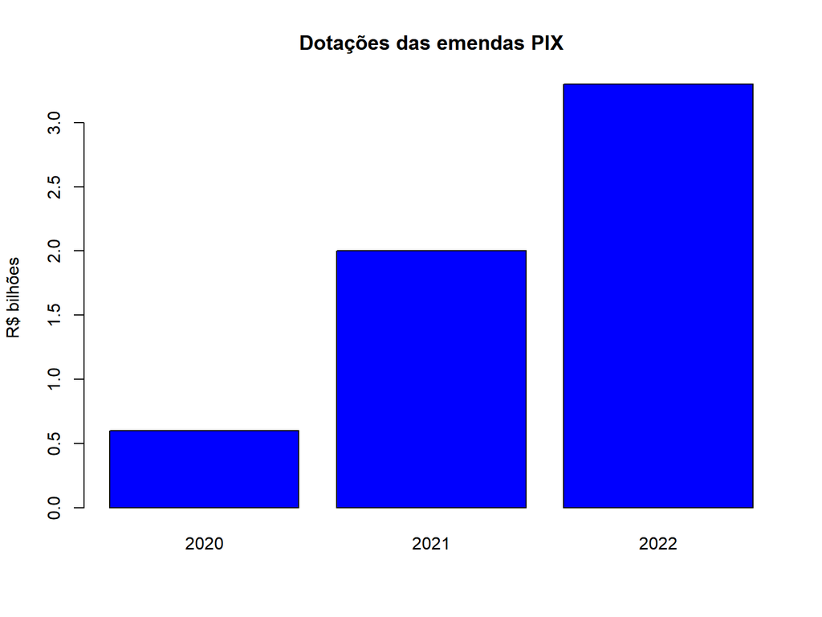

Para a LOA 2023, as emendas PIX poderão alcançar, potencialmente, R$ 5,8 bilhões. Isso porque os 594 parlamentares terão direito a uma cota para emendas individuais de R$ 19,7 milhões. Cada um deles poderá destinar até a metade desse valor às emendas PIX.

# Método de pesquisa

Foram coletados, portanto, dados de dotação e de execução (despesas liquidadas) de todas as emendas aprovadas na ação 0EC2 no exercício de 2021. A fonte de consulta foi o Sistema Integrado de Planejamento e Orçament (SIOP), gerenciado pelo Ministério da Economia.

A consulta obtida foi exportada para arquivo Excel, posteriormente lido no Rstudio, onde finalmente foram realizados os testes estatísticos.

Adotou-se o método **T-Student (t-test)**, haja vista sua capacidade de identificar se as médias de dois grupos são realmente diferentes do ponto de vista estatístico. Adotou-se intervalo de confiança de 99%.

# Diferenças de médias

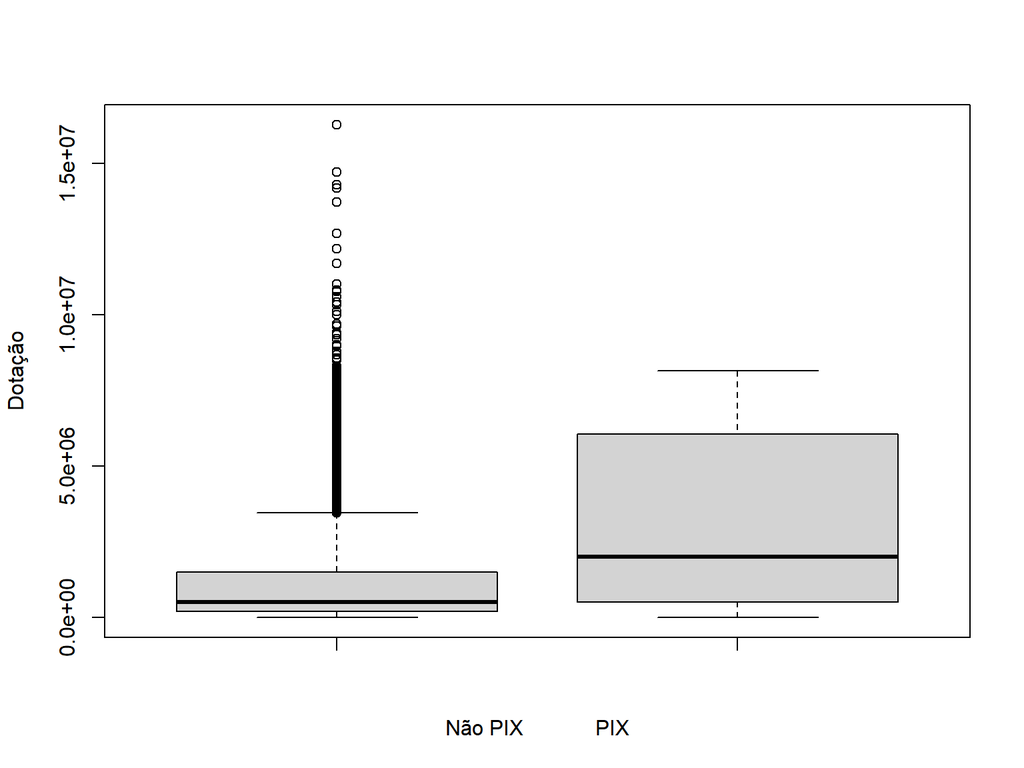

Constatou-se que a média das dotações e a média das liquidações das emendas PIX, em 2021, foram superiores à medias das emendas tradicionais para as mesmas variáveis, tal como demonstrado, em pormenores, neste link: https://paulobijos.github.io/PIX/.

# Obrigado

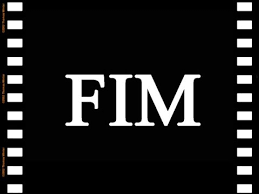